# Data stuff for the workshop

2018-02-20

## 0.1 Summary

```r
rm(list = setdiff(ls(), c("sourceData", "projectData", "entityData", "currentLookup", "currentSecondary", "snlData", "treatyCountries")))
source("../../Functions/Cleaning Functions/Clean Chars.R")
source("../../Functions/Cleaning Functions/Reconcile Values Using Lookups.R")
source("../../Functions/Pipeline Functions/Add Raw Vals to Reconcile Sheet.R")
source("../../Functions/Pipeline Functions/Update Lookup using Reconcile Sheet.R")
library(tidyverse); library(ggthemes); library(kableExtra); library(knitr); library(viridis); library(readxl); library(stringr); library(googlesheets); library(writexl)
if(!exists("sourceData")){ ##so that we only run on first load
    sourceData <- read_csv("../../Data Cleaning/Payment Data Pipeline/data/Current website data/allSource.csv")
    projectData <- read_csv("../../Data Cleaning/Payment Data Pipeline/data/Current website data/allProject.csv") %>%
        mutate(projectPayment = as.numeric(projectPayment))

    entityData <- read_csv("../../Data Cleaning/Payment Data Pipeline/data/Current website data/allEntity.csv") %>%
        mutate(entityPayment = as.numeric(entityPayment))
}
##load snl data
snlData <- read_csv("../Data/SNL Data/Clean Data/snlCompiled.csv")
```

Load the lookup tables and secondary data

```r
if(!exists("currentLookup")){
    gs_auth("/Users/hsubhash/Documents/GitHub/resource-project-data/token.rds")
    currentLookup <- gs_title("Current Lookup - Projects") %>%
        gs_read(ws = "Current Matched Lookup", verbose = F)
    currentSecondary <- gs_title("Current Secondary - Projects") %>%
        gs_read(ws = "Secondary Data", verbose = F)
    currentSecondaryMissing <- gs_title("Current Secondary - Projects") %>%
        gs_read(ws = "Add to Secondary", verbose = F)
    currentSecondary <- bind_rows(currentSecondary, currentSecondaryMissing %>% filter(!is.na(projectType)))
    rm(currentSecondaryMissing)
}
```

First lets setup the project data using the lookup table

```r
projectDataUpdated <- projectData %>%
    left_join(., currentLookup %>%
                  select(1:3), by = c("projectCountry", "projectName" = "rawName")) %>%
    mutate(projectName = ifelse(is.na(finalName), projectName, finalName)) %>%
    select(-finalName)
```

## 0.2 Joint Ventures

These are projects that are reported by multiple companies

```r
##identify the list of projects with multiple reporting companies
jvList <- projectDataUpdated %>%
    group_by(projectCountry, reportingCompany, projectName, reportYear) %>%
    summarise(totPay = sum(projectPayment, na.rm = T)) %>%
    ungroup() %>%
    filter(!is.na(totPay) & totPay != 0 & !str_detect(str_to_lower(projectName), "alberta|columbia|other|general|gulf of mexico|attribu|operated|entity|exploration|united states of")) %>%
    group_by(projectCountry, projectName, reportYear) %>%
    filter(n_distinct(reportingCompany) > 1) %>% ##identify the JVs
    ungroup() %>%
    left_join(., currentSecondary %>% select(projectCountry, finalName, projectType), by = c("projectCountry", "projectName" = "finalName")) %>%
    filter(projectType != "Corporate" & projectName != "x" & projectName != "Bc")

jvProjects <- projectDataUpdated %>%
    filter(paste0(projectCountry, projectName, reportYear) %in% unique(paste0(jvList$projectCountry, jvList$projectName, jvList$reportYear))) %>%
    group_by(projectCountry, reportingCompany, projectName, paymentType, reportYear) %>%
    summarise(sourceID = unique(sourceID), projectPayment = sum(projectPayment, na.rm = T)) %>%
    ungroup() %>%
    group_by(projectCountry, reportingCompany, projectName, reportYear) %>%
    mutate(totPay = sum((projectPayment), na.rm = T)) %>%
    ungroup() %>%
    mutate(proportionPay = projectPayment/totPay) %>%
    left_join(., sourceData %>% select(sourceID, sourceURL, reportingCountry)) %>%
    select(sourceID,1:5, 7:11) %>%
    write_csv(., "Workshop Data/JV Data/jv.csv")
rm(jvProjects, jvList)
```

## 0.3 Gold Data

```r
snlDataGold <- read_csv("../../Data Cleaning/Secondary Data/Projects/Data/Secondary data sources/SNLgoldmines_David.csv") %>%
    select(-lat, -lon, -primaryCommodity, -primaryCommodity_1, -commodityList_1, -commodityList, `totalProdCost_ oz_2015_1`)
```

[output not shown]

```r
goldProjects <- projectDataUpdated %>% ##if there is a final name then replace
    select(-notes, -nrgiNotes) %>%
    left_join(., currentSecondary, by = c("projectCountry", "projectName" = "finalName")) %>%
    select(-projectType, -sources, -notes) %>%
    left_join(., snlData, by = c("snlPropID" = "propertyId")) %>%
    filter(!is.na(snlPropID) & str_detect(str_to_lower(commodity), "gold")) %>% ##identify gold projects with snl ids
    left_join(., snlDataGold, by = c("snlPropID" = "id")) %>%
    select(-snlPropID)
write_xlsx(list(goldSources = sourceData %>% filter(sourceID %in% goldProjects$sourceID),
           goldProjects = goldProjects,
           goldEntityPayments = entityData %>% filter(sourceID %in% goldProjects$sourceID)),
           "Workshop Data/Gold Data/gold as primary and secondary commodity.xlsx")
```

```
[1] "/Users/hsubhash/Documents/GitHub/resource-project-data/Analysis/Scripts/Workshop Data/Gold Data/gold as primary and secondary commodity.xlsx"
```

```r
rm(goldProjects, snlDataGold)
```

## 0.4 Company Datasets

### 0.4.1 Beneficial ownership

There are three types of data that we need to setup.

1. List of sources where payments were made to a project that we have identified as “corporate” in a country in which there were no actual payments made to mines or oil and gas projects (that we have identified).
2. List of sources where payments were made to a govt entity in a country were there were no actual mine or oil and gas project payments.
3. List of sources where payments were made to a govt entity in a country were there were no project payments (corporate, mine or oil and gas)

Known Issues :

1. Companies are recorded in the mandatory disclosures as being located in a project country but are actually located elsewhere.
2. Vague project names that make it hard to identify whether a payment was made to an actual mine or oil & gas field.

First lets setup the project data so that it has information on project type by merging in secondary data. We also some additional data on tax treaties to this data.

```r
# if(!exists("treatyCountries")){
#     treatyCountries <- read_csv("../../Data Cleaning/Secondary Data/Countries/Data/Tax treaties/Tax Countries.csv") %>%
#         mutate(country1 = cleanValues(rawVals = country1, "Country"), country2 = cleanValues(country2, "Country")) %>%
#     distinct()
# }
# treatyRecipient <- treatyCountries %>%
#     group_by(country2) %>%
#     summarise(mineCountry = paste(country1, collapse = "; "))
sourceListCompany <- projectDataUpdated %>% ##if there is a final name then replace
    select(-notes, -nrgiNotes) %>%
    filter(projectCountry != "Could not be identified") %>%
    left_join(., currentSecondary, by = c("projectCountry", "projectName" = "finalName")) %>%
    left_join(., sourceData %>% select(sourceID, reportingCountry), by = "sourceID")
# %>%
#     left_join(., treatyRecipient, by = c("projectCountry" = "country2"))
```

Now lets look at the first type.

```r
type1 <- sourceListCompany %>%
    filter(!is.na(projectType)) %>%
    group_by(sourceID) %>%
    mutate(nonCorporateCountries = paste(sort(unique(c(projectCountry[projectType %in% c("Oil & Gas", "Mining")], reportingCountry))), collapse = ", ")) %>%
    ungroup() %>%
    filter(!str_detect(nonCorporateCountries, projectCountry) & projectType == "Corporate") %>%
    select(1:5, projectType, nonCorporateCountries, 6:7)
```

Now lets to type 2.

```r
##list of sources that are not corporate (or missing) and collate the country names.
type2List <- sourceListCompany %>%
    filter(projectType != "Corporate" | is.na(projectType)) %>%
    group_by(sourceID) %>%
    summarise(projectCountryList = paste(sort(unique(c(projectCountry, reportingCountry))), collapse = ", "))
type2 <- entityData %>%
    filter(entityCountry != "Could not be identified") %>%
    left_join(., type2List, by = "sourceID") %>%
    filter(!str_detect(projectCountryList, entityCountry)) %>%
    distinct() %>%
    select(1:5, projectCountryList, 6:7)
```

type 3.

```r
type3List <- sourceListCompany %>%
    group_by(sourceID) %>%
    summarise(projectCountryList = paste(sort(unique(c(projectCountry, reportingCountry))), collapse = ", "))
type3 <- entityData %>%
    filter(entityCountry != "Could not be identified") %>%
    left_join(., type3List, by = "sourceID") %>%
    filter(!str_detect(projectCountryList, entityCountry)) %>%
    distinct() %>%
    select(1:5, projectCountryList, 6:7)
```

save the files along with the source project and entity data.

```r
sourceIDList <- unique(c(type1$sourceID, type2$sourceID, type3$sourceID))
write_xlsx(list(allTypesSources = sourceData %>% filter(sourceID %in% sourceIDList),
                type1 = type1,
                type2 = type2,
                type3 = type3,
                allTypesProject = projectData %>% filter(sourceID %in% sourceIDList),
                allTypesEntityData = entityData %>% filter(sourceID %in% sourceIDList)),
           "Workshop Data/Company Data/Potential Companies to Investigate.xlsx")
```

```
[1] "/Users/hsubhash/Documents/GitHub/resource-project-data/Analysis/Scripts/Workshop Data/Company Data/Potential Companies to Investigate.xlsx"
```

```r
rm(type1, type2List, type2, type3List, type3, sourceListCompany, sourceIDList)
```

### 0.4.2 Single Asset

The next type of company data that we are interested in are those that report payments to a single project within a country in a disclosure

```r
singleAssetList <- projectDataUpdated %>%
    left_join(., currentSecondary %>% select(projectCountry, finalName, projectType), by = c("projectCountry", "projectName" = "finalName")) %>%
    filter(projectType != "Corporate" & !is.na(projectType)) %>%
    group_by(sourceID, projectCountry, projectName) %>%
    summarise(reportingCompany = unique(reportingCompany),totPay = sum(projectPayment, na.rm = T)) %>%
    ungroup() %>%
    filter(totPay != 0 & !is.na(totPay)) %>%
    group_by(sourceID, projectCountry) %>%
    filter(n() == 1)
write_xlsx(list(singleAssetSources = sourceData %>% filter(sourceID %in% singleAssetList$sourceID),
                singleAssetList = singleAssetList,
                singleAssetProject = projectData %>% filter(sourceID %in% singleAssetList$sourceID),
                singleAssetEntityData = entityData %>% filter(sourceID %in% singleAssetList$sourceID)),
           "Workshop Data/Company Data/Single Asset Companies to Investigate.xlsx")
```

```
[1] "/Users/hsubhash/Documents/GitHub/resource-project-data/Analysis/Scripts/Workshop Data/Company Data/Single Asset Companies to Investigate.xlsx"
```

### 0.4.3 Mines that don’t pay taxes

```r
lowTaxMines <- projectDataUpdated %>%
    select(-nrgiNotes) %>%
    left_join(., currentSecondary %>% select(projectCountry, finalName, projectType, snlPropID), by = c("projectCountry", "projectName" = "finalName")) %>%
    filter(!is.na(snlPropID)) %>%
    left_join(., snlData %>% select(propertyId, actualStartUpYear, developmentStage, primaryCommodity), by = c("snlPropID" = "propertyId")) %>%
    mutate(age = (2018 - as.numeric(actualStartUpYear))) %>%
    filter(!is.na(age) & developmentStage == "Operating") %>%
    group_by(snlPropID) %>%
    filter(sum(projectPayment[paymentType == "Taxes"], na.rm = T) < 1e6) %>%
    select(1:5, 11, 14, 13, 12, 6, 7, notes)
```

```
NAs introduced by coercion
```

```r
write_xlsx(list(lowTaxSources = sourceData %>% filter(sourceID %in% lowTaxMines$sourceID),
                lowTaxProjectsPayments = lowTaxMines,
                lowTaxMinesEntityData = entityData %>% filter(sourceID %in% lowTaxMines$sourceID)),
           "Workshop Data/Mine Data/Low Tax Mines.xlsx")
```

```
[1] "/Users/hsubhash/Documents/GitHub/resource-project-data/Analysis/Scripts/Workshop Data/Mine Data/Low Tax Mines.xlsx"
```

```r
rm(lowTaxMines)
```

### 0.4.4 Link mandatory disclosures to the Goldcorp productions data

```r
goldCorp <- read_csv("Workshop Data/Mine Data/goldcorp-clean-data.csv") %>%
    filter(!project %in% c("Total")) %>%
    mutate(value = case_when(
        multiplier == "Million" ~ value * 1e6,
        multiplier == "Thousand" ~ value * 1e3,
        TRUE ~ value
    )) %>%
    group_by(project, measure, year) %>%
    mutate(valueSum = sum(value, na.rm = T), valueMean = mean(value, na.rm = T)) %>%
    select(project, measure, year, multiplier, valueSum, valueMean, Unit) %>%
    arrange(project, measure, year) %>%
    distinct() %>%
    ungroup() %>%
    mutate(value = if_else(str_detect(str_to_lower(measure), "average"), valueMean, valueSum)) %>%
    mutate(measure = str_replace_all(measure, "\\(|\\)", "") %>%
               camelCase(.) %>% paste(., year, sep = "_"))
goldSecondary <- tibble(projectCountry = c("Argentina", "Argentina", "Mexico", "Canada", "Mexico", "United States of America", "Guatemala", "Canada", "Mexico", "Mexico", "Canada", "Dominican Republic", "Canada","United States of America"),rawGoldNames = unique(goldCorp$project) %>% sort()) %>%
    left_join(., currentSecondary, c("projectCountry", "rawGoldNames" = "finalName"))
goldCorp <- left_join(goldCorp, goldSecondary, by = c("project" = "rawGoldNames")) %>%
    filter(project != "Penasquito Sulphide" & value != 0 & !is.na(value)) %>%
    group_by(measure) %>%
    filter(year == max(year, na.rm = T)) %>%
    spread(key = measure, value = value) %>%
    left_join(., projectDataUpdated, by = c("projectCountry", "project" = "projectName"))
rm(goldSecondary)
```

## 0.5 Tunisia data for Charles

These are the projects that are in RP and in Tunisia.

```r
projectDataTunisia <- projectDataUpdated %>%
    filter(projectCountry == "Tunisia")
entityDataTunisia <- entityData %>%
    filter(entityCountry == "Tunisia")
sourceDataTunisia <- sourceData %>%
    filter(sourceID %in% c(projectDataTunisia$sourceID, entityDataTunisia$sourceID))
write_xlsx(list(sourceTunisia = sourceDataTunisia,
                projectsTunisia = projectDataTunisia,
                entitiesTunisia = entityDataTunisia,
                projectNames = tibble(projects = projectDataTunisia$projectName) %>% unique()),
           "Workshop Data/Mine Data/Tunisia Mines.xlsx")
```

```
[1] "/Users/hsubhash/Documents/GitHub/resource-project-data/Analysis/Scripts/Workshop Data/Mine Data/Tunisia Mines.xlsx"
```

```r
rm(sourceDataTunisia, projectDataTunisia, entityDataTunisia)
```

### 0.5.1 Charts for scaling project level analysis

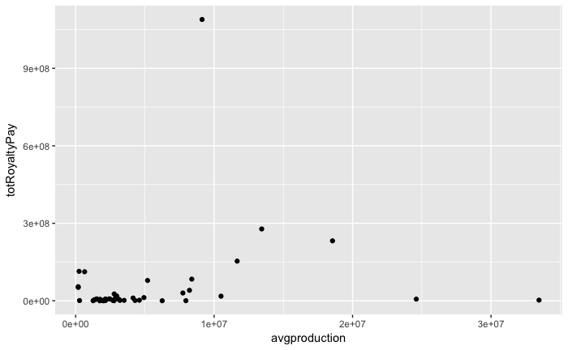

```r
projectDataUpdatedSNL <- left_join(projectDataUpdated, currentSecondary, by = c("projectCountry", "projectName" = "finalName")) %>%
    filter(!is.na(snlPropID)) %>%
    left_join(., snlData %>% select(propertyId, avgproduction), by = c("snlPropID" = "propertyId")) %>%
    filter(avgproduction > quantile(avgproduction, 0.6, na.rm = T)) %>%
    select(sourceID, reportingCompany, projectCountry, projectName, snlPropID, avgproduction, paymentType, projectPayment) %>%
    filter(paymentType == "Royalties") %>%
    group_by(snlPropID, paymentType) %>%
    summarise(totRoyaltyPay = sum(projectPayment, na.rm = T), avgproduction = unique(avgproduction)) %>%
    ggplot(., aes(x = avgproduction, y = totRoyaltyPay)) +
    geom_point()
projectDataUpdatedSNL
```

## 0.6 Charts for workshop presentation for david

```r
names(corpProfits)
```

```
 [1] "SNLId"                              "ownerSNL"
 [3] "Company Name, Short"                "Trading Symbol & Exchange"
 [5] "Net Income before Taxes (Reported)" "Net Income (Reported)"
 [7] "Dividend Payout Ratio (%)"          "sourceID"
 [9] "reportingCompany"                   "reportYear"
[11] "projectCountry"                     "projectName"
[13] "paymentType"                        "projectPayment"
[15] "notes.x"                            "nrgiNotes"
[17] "projectType"                        "commodity"
[19] "lat"                                "lon"
[21] "locationType"                       "sources"
[23] "notes.y"
```

[output not shown]

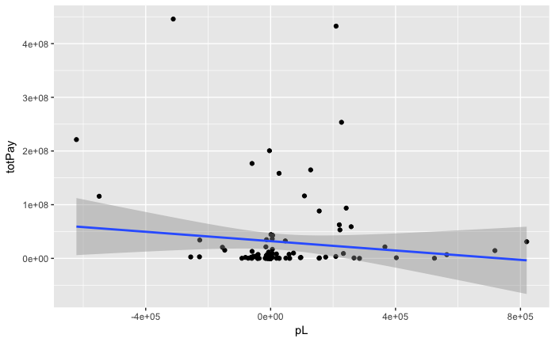

```r
corpProfits %>%
    filter(paymentType == "Taxes") %>%
    group_by(SNLId) %>%
    summarise(totPay = sum(projectPayment, na.rm = T), pL = unique((as.numeric(`Net Income before Taxes (Reported)`)))) %>%
    filter(!is.na(pL) & abs(pL) < 1e6) %>%
    mutate(logPL = log(pL)) %>%
    ggplot(., aes(x = pL, y = totPay)) + geom_point() + geom_smooth(method = 'lm')
```

```r
library(ggthemes); library(viridis)
plChart <- corpProfits %>%
    mutate(pL = as.numeric(`Net Income before Taxes (Reported)`)) %>%
    filter(!is.na(pL)) %>%
    mutate(pLCat = case_when(
        pL <= 0 ~ "Loss",
        pL > 0 ~ "Profit"
    )) %>%
    group_by(pLCat, paymentType) %>%
    summarise(totPay = mean(projectPayment, na.rm = T)) %>%
    filter(!is.na(paymentType) & paymentType != "Could not be identified") %>%
    ggplot(., aes(x = pLCat, y = totPay, fill = paymentType)) +
    geom_bar(stat = "identity", position = "dodge") +
    scale_y_continuous(expand = c(0.065, 0)) +
    geom_text(aes(label = if_else(totPay < 1e9, format(round(totPay / 1e6, 1), trim = TRUE), format(round(totPay / 1e9, 1), trim = TRUE))), vjust = -1.25, position = position_dodge(width = 0.9), size = 6) +
    geom_text(aes(label = if_else(totPay < 1e9, "M", "B")), vjust = -.15, position = position_dodge(width = 0.9), size = 5) +
    theme_tufte() +
    theme(
        legend.position = "top",
        legend.title = element_blank(),
        axis.text.y = element_blank(),
        axis.line = element_blank(),
        axis.ticks = element_blank(),
        axis.title = element_blank(),
        axis.text.x = element_text(size = 18),
        legend.text = element_text(size = 14)
    )
```

```
NAs introduced by coercion
```

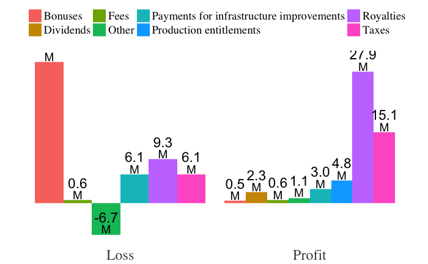

```r
plChart
```

```r
png(file = "../Plots/Workshop/Presentation/profitLoss.png", height = 800, width = 1200, res = 100)
plChart
dev.off()
```